# Risk Factor Analysis

## Outcome Variable

**Outcome Variable:** ever_wasted

## Predictor Variables

**Intervention Variable:** perdiar6

**Adjustment Set:**

unadjusted

## Stratifying Variables

The analysis was stratified on these variable(s):

- agecat
- studyid
- country

## Data Summary

| agecat | studyid | country | perdiar6 | ever_wasted | n_cell | n |
| --- | --- | --- | --- | --- | --- | --- |
| 0-24 months (no birth wast) | CMIN | BANGLADESH | 0% | 0 | 54 | 268 |
| 0-24 months (no birth wast) | CMIN | BANGLADESH | 0% | 1 | 39 | 268 |
| 0-24 months (no birth wast) | CMIN | BANGLADESH | (0%, 5%] | 0 | 40 | 268 |
| 0-24 months (no birth wast) | CMIN | BANGLADESH | (0%, 5%] | 1 | 22 | 268 |
| 0-24 months (no birth wast) | CMIN | BANGLADESH | >5% | 0 | 59 | 268 |
| 0-24 months (no birth wast) | CMIN | BANGLADESH | >5% | 1 | 54 | 268 |
| 0-24 months (no birth wast) | CONTENT | PERU | 0% | 0 | 114 | 215 |
| 0-24 months (no birth wast) | CONTENT | PERU | 0% | 1 | 1 | 215 |
| 0-24 months (no birth wast) | CONTENT | PERU | (0%, 5%] | 0 | 42 | 215 |
| 0-24 months (no birth wast) | CONTENT | PERU | (0%, 5%] | 1 | 1 | 215 |
| 0-24 months (no birth wast) | CONTENT | PERU | >5% | 0 | 55 | 215 |
| 0-24 months (no birth wast) | CONTENT | PERU | >5% | 1 | 2 | 215 |
| 0-24 months (no birth wast) | EE | PAKISTAN | 0% | 0 | 159 | 377 |
| 0-24 months (no birth wast) | EE | PAKISTAN | 0% | 1 | 181 | 377 |
| 0-24 months (no birth wast) | EE | PAKISTAN | (0%, 5%] | 0 | 14 | 377 |
| 0-24 months (no birth wast) | EE | PAKISTAN | (0%, 5%] | 1 | 21 | 377 |
| 0-24 months (no birth wast) | EE | PAKISTAN | >5% | 0 | 1 | 377 |
| 0-24 months (no birth wast) | EE | PAKISTAN | >5% | 1 | 1 | 377 |
| 0-24 months (no birth wast) | MAL-ED | BANGLADESH | 0% | 0 | 65 | 263 |
| 0-24 months (no birth wast) | MAL-ED | BANGLADESH | 0% | 1 | 20 | 263 |
| 0-24 months (no birth wast) | MAL-ED | BANGLADESH | (0%, 5%] | 0 | 75 | 263 |
| 0-24 months (no birth wast) | MAL-ED | BANGLADESH | (0%, 5%] | 1 | 23 | 263 |
| 0-24 months (no birth wast) | MAL-ED | BANGLADESH | >5% | 0 | 65 | 263 |
| 0-24 months (no birth wast) | MAL-ED | BANGLADESH | >5% | 1 | 15 | 263 |
| 0-24 months (no birth wast) | MAL-ED | BRAZIL | 0% | 0 | 205 | 233 |
| 0-24 months (no birth wast) | MAL-ED | BRAZIL | 0% | 1 | 11 | 233 |
| 0-24 months (no birth wast) | MAL-ED | BRAZIL | (0%, 5%] | 0 | 14 | 233 |
| 0-24 months (no birth wast) | MAL-ED | BRAZIL | (0%, 5%] | 1 | 1 | 233 |
| 0-24 months (no birth wast) | MAL-ED | BRAZIL | >5% | 0 | 1 | 233 |
| 0-24 months (no birth wast) | MAL-ED | BRAZIL | >5% | 1 | 1 | 233 |

[output cut: 204 more lines]

The following strata were considered:

- agecat: 0-24 months (no birth wast), studyid: CMIN, country: BANGLADESH
- agecat: 0-24 months (no birth wast), studyid: CONTENT, country: PERU
- agecat: 0-24 months (no birth wast), studyid: EE, country: PAKISTAN
- agecat: 0-24 months (no birth wast), studyid: MAL-ED, country: BANGLADESH
- agecat: 0-24 months (no birth wast), studyid: MAL-ED, country: BRAZIL
- agecat: 0-24 months (no birth wast), studyid: MAL-ED, country: INDIA
- agecat: 0-24 months (no birth wast), studyid: MAL-ED, country: NEPAL
- agecat: 0-24 months (no birth wast), studyid: MAL-ED, country: PERU
- agecat: 0-24 months (no birth wast), studyid: MAL-ED, country: SOUTH AFRICA
- agecat: 0-24 months (no birth wast), studyid: MAL-ED, country: TANZANIA, UNITED REPUBLIC OF
- agecat: 0-24 months (no birth wast), studyid: NIH-Birth, country: BANGLADESH
- agecat: 0-24 months (no birth wast), studyid: NIH-Crypto, country: BANGLADESH
- agecat: 0-24 months (no birth wast), studyid: PROVIDE, country: BANGLADESH
- agecat: 0-6 months (no birth wast), studyid: CMIN, country: BANGLADESH
- agecat: 0-6 months (no birth wast), studyid: CONTENT, country: PERU
- agecat: 0-6 months (no birth wast), studyid: EE, country: PAKISTAN
- agecat: 0-6 months (no birth wast), studyid: MAL-ED, country: BANGLADESH
- agecat: 0-6 months (no birth wast), studyid: MAL-ED, country: BRAZIL
- agecat: 0-6 months (no birth wast), studyid: MAL-ED, country: INDIA
- agecat: 0-6 months (no birth wast), studyid: MAL-ED, country: NEPAL
- agecat: 0-6 months (no birth wast), studyid: MAL-ED, country: PERU
- agecat: 0-6 months (no birth wast), studyid: MAL-ED, country: SOUTH AFRICA
- agecat: 0-6 months (no birth wast), studyid: MAL-ED, country: TANZANIA, UNITED REPUBLIC OF
- agecat: 0-6 months (no birth wast), studyid: NIH-Birth, country: BANGLADESH
- agecat: 0-6 months (no birth wast), studyid: NIH-Crypto, country: BANGLADESH
- agecat: 0-6 months (no birth wast), studyid: PROVIDE, country: BANGLADESH
- agecat: 6-24 months, studyid: CMIN, country: BANGLADESH
- agecat: 6-24 months, studyid: CONTENT, country: PERU
- agecat: 6-24 months, studyid: EE, country: PAKISTAN
- agecat: 6-24 months, studyid: MAL-ED, country: BANGLADESH
- agecat: 6-24 months, studyid: MAL-ED, country: BRAZIL
- agecat: 6-24 months, studyid: MAL-ED, country: INDIA
- agecat: 6-24 months, studyid: MAL-ED, country: NEPAL
- agecat: 6-24 months, studyid: MAL-ED, country: PERU
- agecat: 6-24 months, studyid: MAL-ED, country: SOUTH AFRICA
- agecat: 6-24 months, studyid: MAL-ED, country: TANZANIA, UNITED REPUBLIC OF
- agecat: 6-24 months, studyid: NIH-Birth, country: BANGLADESH
- agecat: 6-24 months, studyid: NIH-Crypto, country: BANGLADESH
- agecat: 6-24 months, studyid: PROVIDE, country: BANGLADESH

### Dropped Strata

Some strata were dropped due to rare outcomes:

- agecat: 0-24 months (no birth wast), studyid: CONTENT, country: PERU
- agecat: 0-24 months (no birth wast), studyid: EE, country: PAKISTAN
- agecat: 0-24 months (no birth wast), studyid: MAL-ED, country: BRAZIL
- agecat: 0-24 months (no birth wast), studyid: MAL-ED, country: SOUTH AFRICA
- agecat: 0-24 months (no birth wast), studyid: MAL-ED, country: TANZANIA, UNITED REPUBLIC OF
- agecat: 0-6 months (no birth wast), studyid: CONTENT, country: PERU
- agecat: 0-6 months (no birth wast), studyid: EE, country: PAKISTAN
- agecat: 0-6 months (no birth wast), studyid: MAL-ED, country: BRAZIL
- agecat: 0-6 months (no birth wast), studyid: MAL-ED, country: NEPAL
- agecat: 0-6 months (no birth wast), studyid: MAL-ED, country: PERU
- agecat: 0-6 months (no birth wast), studyid: MAL-ED, country: SOUTH AFRICA
- agecat: 0-6 months (no birth wast), studyid: MAL-ED, country: TANZANIA, UNITED REPUBLIC OF
- agecat: 6-24 months, studyid: CONTENT, country: PERU
- agecat: 6-24 months, studyid: EE, country: PAKISTAN
- agecat: 6-24 months, studyid: MAL-ED, country: BRAZIL
- agecat: 6-24 months, studyid: MAL-ED, country: PERU
- agecat: 6-24 months, studyid: MAL-ED, country: SOUTH AFRICA
- agecat: 6-24 months, studyid: MAL-ED, country: TANZANIA, UNITED REPUBLIC OF

## Methods Detail

We’re interested in the causal parameters $E[Y_a]$ for all values of $a \in \mathcal{A}$. These parameters represent the mean outcome if, possibly contrary to fact, we intervened to set all units to have $A=a$. Under the randomization and positivity assumptions, these are identified by the statistical parameters $\psi_a=E_W[E_{Y|A,W}(Y|A=a,W)]$. In addition, we’re interested in the mean of $Y$, $E[Y]$ under no intervention (the observed mean). We will estimate these parameters by using SuperLearner to fit the relevant likelihood factors – $E_{Y|A,W}(Y|A=a,W)$ and $p(A=a|W)$, and then updating our likelihood fit using a joint TMLE.

For unadjusted analyses ($W=\{\}$), initial likelihoods were estimated using Lrnr_glm to estimate the simple $E(Y|A)$ and Lrnr_mean to estimate $p(A)$. For adjusted analyses, a small library containing Lrnr_glmnet, Lrnr_xgboost, and Lrnr_mean was used.

Having estimated these parameters, we will then use the delta method to estimate relative risks and attributable risks relative to a prespecified baseline level of $A$.

# Results Detail

## Results Plots

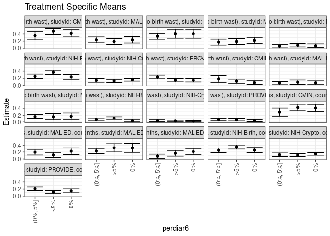

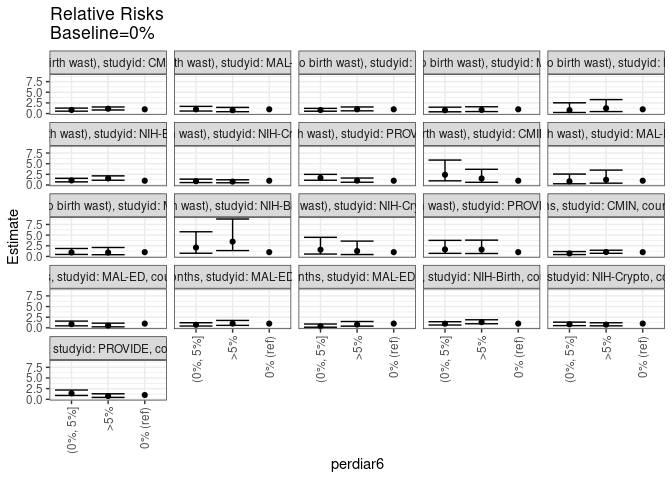

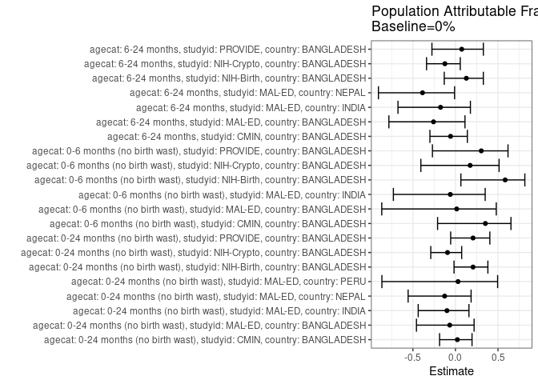

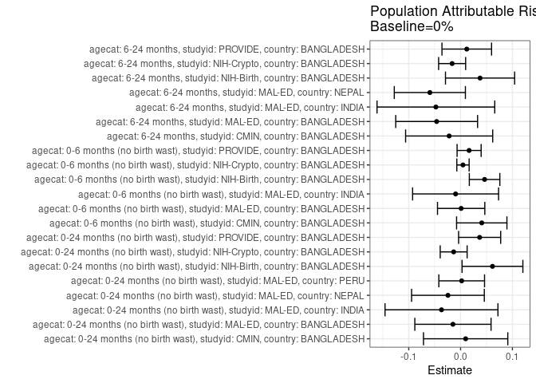

## Results Table

### Parameter: TSM

| agecat | studyid | country | intervention_level | baseline_level | estimate | ci_lower | ci_upper |
| --- | --- | --- | --- | --- | --- | --- | --- |
| 0-24 months (no birth wast) | CMIN | BANGLADESH | 0% | NA | 0.4193548 | 0.3188783 | 0.5198314 |
| 0-24 months (no birth wast) | CMIN | BANGLADESH | (0%, 5%] | NA | 0.3548387 | 0.2355186 | 0.4741588 |
| 0-24 months (no birth wast) | CMIN | BANGLADESH | >5% | NA | 0.4778761 | 0.3856051 | 0.5701471 |
| 0-24 months (no birth wast) | MAL-ED | BANGLADESH | 0% | NA | 0.2352941 | 0.1449461 | 0.3256421 |
| 0-24 months (no birth wast) | MAL-ED | BANGLADESH | (0%, 5%] | NA | 0.2346939 | 0.1506259 | 0.3187619 |
| 0-24 months (no birth wast) | MAL-ED | BANGLADESH | >5% | NA | 0.1875000 | 0.1018075 | 0.2731925 |
| 0-24 months (no birth wast) | MAL-ED | INDIA | 0% | NA | 0.4067797 | 0.2811783 | 0.5323810 |
| 0-24 months (no birth wast) | MAL-ED | INDIA | (0%, 5%] | NA | 0.3359375 | 0.2539474 | 0.4179276 |
| 0-24 months (no birth wast) | MAL-ED | INDIA | >5% | NA | 0.4067797 | 0.2811783 | 0.5323810 |
| 0-24 months (no birth wast) | MAL-ED | NEPAL | 0% | NA | 0.2168675 | 0.1280222 | 0.3057127 |
| 0-24 months (no birth wast) | MAL-ED | NEPAL | (0%, 5%] | NA | 0.1710526 | 0.0862166 | 0.2558886 |
| 0-24 months (no birth wast) | MAL-ED | NEPAL | >5% | NA | 0.1875000 | 0.1017911 | 0.2732089 |
| 0-24 months (no birth wast) | MAL-ED | PERU | 0% | NA | 0.0674157 | 0.0152365 | 0.1195950 |
| 0-24 months (no birth wast) | MAL-ED | PERU | (0%, 5%] | NA | 0.0537634 | 0.0078468 | 0.0996801 |
| 0-24 months (no birth wast) | MAL-ED | PERU | >5% | NA | 0.0833333 | 0.0338005 | 0.1328661 |
| 0-24 months (no birth wast) | NIH-Birth | BANGLADESH | 0% | NA | 0.2356688 | 0.1692252 | 0.3021124 |
| 0-24 months (no birth wast) | NIH-Birth | BANGLADESH | (0%, 5%] | NA | 0.2527473 | 0.1895567 | 0.3159378 |
| 0-24 months (no birth wast) | NIH-Birth | BANGLADESH | >5% | NA | 0.3653846 | 0.3068039 | 0.4239653 |
| 0-24 months (no birth wast) | NIH-Crypto | BANGLADESH | 0% | NA | 0.1565934 | 0.1192348 | 0.1939520 |
| 0-24 months (no birth wast) | NIH-Crypto | BANGLADESH | (0%, 5%] | NA | 0.1387283 | 0.0871858 | 0.1902709 |
| 0-24 months (no birth wast) | NIH-Crypto | BANGLADESH | >5% | NA | 0.1244240 | 0.0804794 | 0.1683685 |
| 0-24 months (no birth wast) | PROVIDE | BANGLADESH | 0% | NA | 0.1408451 | 0.0940951 | 0.1875950 |
| 0-24 months (no birth wast) | PROVIDE | BANGLADESH | (0%, 5%] | NA | 0.2355212 | 0.1838067 | 0.2872357 |
| 0-24 months (no birth wast) | PROVIDE | BANGLADESH | >5% | NA | 0.1441860 | 0.0971970 | 0.1911751 |
| 0-6 months (no birth wast) | CMIN | BANGLADESH | 0% | NA | 0.0752688 | 0.0215487 | 0.1289889 |
| 0-6 months (no birth wast) | CMIN | BANGLADESH | (0%, 5%] | NA | 0.1803279 | 0.0836673 | 0.2769885 |
| 0-6 months (no birth wast) | CMIN | BANGLADESH | >5% | NA | 0.1150442 | 0.0561033 | 0.1739852 |
| 0-6 months (no birth wast) | MAL-ED | BANGLADESH | 0% | NA | 0.0714286 | 0.0162485 | 0.1266087 |
| 0-6 months (no birth wast) | MAL-ED | BANGLADESH | (0%, 5%] | NA | 0.0612245 | 0.0136681 | 0.1087809 |
| 0-6 months (no birth wast) | MAL-ED | BANGLADESH | >5% | NA | 0.0875000 | 0.0254625 | 0.1495375 |
| 0-6 months (no birth wast) | MAL-ED | INDIA | 0% | NA | 0.1694915 | 0.0735603 | 0.2654227 |
| 0-6 months (no birth wast) | MAL-ED | INDIA | (0%, 5%] | NA | 0.1574803 | 0.0939997 | 0.2209609 |
| 0-6 months (no birth wast) | MAL-ED | INDIA | >5% | NA | 0.1551724 | 0.0618003 | 0.2485445 |
| 0-6 months (no birth wast) | NIH-Birth | BANGLADESH | 0% | NA | 0.0328947 | 0.0045155 | 0.0612740 |
| 0-6 months (no birth wast) | NIH-Birth | BANGLADESH | (0%, 5%] | NA | 0.0685714 | 0.0310957 | 0.1060471 |
| 0-6 months (no birth wast) | NIH-Birth | BANGLADESH | >5% | NA | 0.1141732 | 0.0750295 | 0.1533169 |
| 0-6 months (no birth wast) | NIH-Crypto | BANGLADESH | 0% | NA | 0.0220994 | 0.0069456 | 0.0372533 |
| 0-6 months (no birth wast) | NIH-Crypto | BANGLADESH | (0%, 5%] | NA | 0.0348837 | 0.0074443 | 0.0623232 |
| 0-6 months (no birth wast) | NIH-Crypto | BANGLADESH | >5% | NA | 0.0279070 | 0.0058762 | 0.0499377 |
| 0-6 months (no birth wast) | PROVIDE | BANGLADESH | 0% | NA | 0.0377358 | 0.0120660 | 0.0634057 |
| 0-6 months (no birth wast) | PROVIDE | BANGLADESH | (0%, 5%] | NA | 0.0620155 | 0.0325642 | 0.0914668 |
| 0-6 months (no birth wast) | PROVIDE | BANGLADESH | >5% | NA | 0.0610329 | 0.0288605 | 0.0932053 |
| 6-24 months | CMIN | BANGLADESH | 0% | NA | 0.4069767 | 0.3029409 | 0.5110126 |
| 6-24 months | CMIN | BANGLADESH | (0%, 5%] | NA | 0.2881356 | 0.1723425 | 0.4039287 |
| 6-24 months | CMIN | BANGLADESH | >5% | NA | 0.4205607 | 0.3268395 | 0.5142820 |
| 6-24 months | MAL-ED | BANGLADESH | 0% | NA | 0.2253521 | 0.1279634 | 0.3227408 |
| 6-24 months | MAL-ED | BANGLADESH | (0%, 5%] | NA | 0.1956522 | 0.1144206 | 0.2768838 |
| 6-24 months | MAL-ED | BANGLADESH | >5% | NA | 0.1168831 | 0.0449723 | 0.1887940 |
| 6-24 months | MAL-ED | INDIA | 0% | NA | 0.3200000 | 0.1904258 | 0.4495742 |
| 6-24 months | MAL-ED | INDIA | (0%, 5%] | NA | 0.2301587 | 0.1565036 | 0.3038139 |
| 6-24 months | MAL-ED | INDIA | >5% | NA | 0.3220339 | 0.2025518 | 0.4415160 |
| 6-24 months | MAL-ED | NEPAL | 0% | NA | 0.2125000 | 0.1226674 | 0.3023326 |
| 6-24 months | MAL-ED | NEPAL | (0%, 5%] | NA | 0.0789474 | 0.0181929 | 0.1397019 |
| 6-24 months | MAL-ED | NEPAL | >5% | NA | 0.1645570 | 0.0826205 | 0.2464934 |
| 6-24 months | NIH-Birth | BANGLADESH | 0% | NA | 0.2558140 | 0.1804511 | 0.3311768 |
| 6-24 months | NIH-Birth | BANGLADESH | (0%, 5%] | NA | 0.2500000 | 0.1852283 | 0.3147717 |
| 6-24 months | NIH-Birth | BANGLADESH | >5% | NA | 0.3443983 | 0.2843514 | 0.4044453 |
| 6-24 months | NIH-Crypto | BANGLADESH | 0% | NA | 0.1478261 | 0.1103481 | 0.1853040 |
| 6-24 months | NIH-Crypto | BANGLADESH | (0%, 5%] | NA | 0.1235294 | 0.0740328 | 0.1730260 |
| 6-24 months | NIH-Crypto | BANGLADESH | >5% | NA | 0.1116279 | 0.0695058 | 0.1537500 |
| 6-24 months | PROVIDE | BANGLADESH | 0% | NA | 0.1490683 | 0.0940093 | 0.2041274 |
| 6-24 months | PROVIDE | BANGLADESH | (0%, 5%] | NA | 0.2080000 | 0.1576470 | 0.2583530 |
| 6-24 months | PROVIDE | BANGLADESH | >5% | NA | 0.1127451 | 0.0693081 | 0.1561821 |

### Parameter: E(Y)

| agecat | studyid | country | intervention_level | baseline_level | estimate | ci_lower | ci_upper |
| --- | --- | --- | --- | --- | --- | --- | --- |
| 0-24 months (no birth wast) | CMIN | BANGLADESH | NA | NA | 0.4291045 | 0.3697365 | 0.4884725 |
| 0-24 months (no birth wast) | MAL-ED | BANGLADESH | NA | NA | 0.2205323 | 0.1703290 | 0.2707357 |
| 0-24 months (no birth wast) | MAL-ED | INDIA | NA | NA | 0.3699187 | 0.3094659 | 0.4303715 |
| 0-24 months (no birth wast) | MAL-ED | NEPAL | NA | NA | 0.1924686 | 0.1423823 | 0.2425550 |
| 0-24 months (no birth wast) | MAL-ED | PERU | NA | NA | 0.0695364 | 0.0408008 | 0.0982721 |
| 0-24 months (no birth wast) | NIH-Birth | BANGLADESH | NA | NA | 0.2971619 | 0.2605332 | 0.3337907 |
| 0-24 months (no birth wast) | NIH-Crypto | BANGLADESH | NA | NA | 0.1432361 | 0.1182149 | 0.1682572 |
| 0-24 months (no birth wast) | PROVIDE | BANGLADESH | NA | NA | 0.1775837 | 0.1489858 | 0.2061816 |
| 0-6 months (no birth wast) | CMIN | BANGLADESH | NA | NA | 0.1161049 | 0.0776073 | 0.1546024 |
| 0-6 months (no birth wast) | MAL-ED | BANGLADESH | NA | NA | 0.0725191 | 0.0410556 | 0.1039825 |
| 0-6 months (no birth wast) | MAL-ED | INDIA | NA | NA | 0.1598361 | 0.1137612 | 0.2059110 |
| 0-6 months (no birth wast) | NIH-Birth | BANGLADESH | NA | NA | 0.0791738 | 0.0571996 | 0.1011481 |
| 0-6 months (no birth wast) | NIH-Crypto | BANGLADESH | NA | NA | 0.0267023 | 0.0151493 | 0.0382553 |
| 0-6 months (no birth wast) | PROVIDE | BANGLADESH | NA | NA | 0.0541728 | 0.0371844 | 0.0711612 |
| 6-24 months | CMIN | BANGLADESH | NA | NA | 0.3849206 | 0.3247254 | 0.4451159 |
| 6-24 months | MAL-ED | BANGLADESH | NA | NA | 0.1791667 | 0.1305478 | 0.2277856 |
| 6-24 months | MAL-ED | INDIA | NA | NA | 0.2723404 | 0.2153029 | 0.3293779 |
| 6-24 months | MAL-ED | NEPAL | NA | NA | 0.1531915 | 0.1070438 | 0.1993392 |
| 6-24 months | NIH-Birth | BANGLADESH | NA | NA | 0.2933579 | 0.2549918 | 0.3317241 |
| 6-24 months | NIH-Crypto | BANGLADESH | NA | NA | 0.1315068 | 0.1069744 | 0.1560393 |
| 6-24 months | PROVIDE | BANGLADESH | NA | NA | 0.1609756 | 0.1319065 | 0.1900447 |

### Parameter: RR

| agecat | studyid | country | intervention_level | baseline_level | estimate | ci_lower | ci_upper |
| --- | --- | --- | --- | --- | --- | --- | --- |
| 0-24 months (no birth wast) | CMIN | BANGLADESH | 0% | 0% | 1.0000000 | 1.0000000 | 1.0000000 |
| 0-24 months (no birth wast) | CMIN | BANGLADESH | (0%, 5%] | 0% | 0.8461538 | 0.5599272 | 1.2786954 |
| 0-24 months (no birth wast) | CMIN | BANGLADESH | >5% | 0% | 1.1395507 | 0.8377111 | 1.5501476 |
| 0-24 months (no birth wast) | MAL-ED | BANGLADESH | 0% | 0% | 1.0000000 | 1.0000000 | 1.0000000 |
| 0-24 months (no birth wast) | MAL-ED | BANGLADESH | (0%, 5%] | 0% | 0.9974490 | 0.5899765 | 1.6863458 |
| 0-24 months (no birth wast) | MAL-ED | BANGLADESH | >5% | 0% | 0.7968750 | 0.4386835 | 1.4475352 |
| 0-24 months (no birth wast) | MAL-ED | INDIA | 0% | 0% | 1.0000000 | 1.0000000 | 1.0000000 |
| 0-24 months (no birth wast) | MAL-ED | INDIA | (0%, 5%] | 0% | 0.8258464 | 0.5571463 | 1.2241348 |
| 0-24 months (no birth wast) | MAL-ED | INDIA | >5% | 0% | 1.0000000 | 0.6461868 | 1.5475401 |
| 0-24 months (no birth wast) | MAL-ED | NEPAL | 0% | 0% | 1.0000000 | 1.0000000 | 1.0000000 |
| 0-24 months (no birth wast) | MAL-ED | NEPAL | (0%, 5%] | 0% | 0.7887427 | 0.4145344 | 1.5007561 |
| 0-24 months (no birth wast) | MAL-ED | NEPAL | >5% | 0% | 0.8645833 | 0.4679763 | 1.5973123 |
| 0-24 months (no birth wast) | MAL-ED | PERU | 0% | 0% | 1.0000000 | 1.0000000 | 1.0000000 |
| 0-24 months (no birth wast) | MAL-ED | PERU | (0%, 5%] | 0% | 0.7974910 | 0.2518616 | 2.5251640 |
| 0-24 months (no birth wast) | MAL-ED | PERU | >5% | 0% | 1.2361111 | 0.4658353 | 3.2800664 |
| 0-24 months (no birth wast) | NIH-Birth | BANGLADESH | 0% | 0% | 1.0000000 | 1.0000000 | 1.0000000 |
| 0-24 months (no birth wast) | NIH-Birth | BANGLADESH | (0%, 5%] | 0% | 1.0724681 | 0.7357534 | 1.5632788 |
| 0-24 months (no birth wast) | NIH-Birth | BANGLADESH | >5% | 0% | 1.5504158 | 1.1209642 | 2.1443942 |
| 0-24 months (no birth wast) | NIH-Crypto | BANGLADESH | 0% | 0% | 1.0000000 | 1.0000000 | 1.0000000 |
| 0-24 months (no birth wast) | NIH-Crypto | BANGLADESH | (0%, 5%] | 0% | 0.8859142 | 0.5696847 | 1.3776813 |
| 0-24 months (no birth wast) | NIH-Crypto | BANGLADESH | >5% | 0% | 0.7945671 | 0.5188357 | 1.2168339 |
| 0-24 months (no birth wast) | PROVIDE | BANGLADESH | 0% | 0% | 1.0000000 | 1.0000000 | 1.0000000 |
| 0-24 months (no birth wast) | PROVIDE | BANGLADESH | (0%, 5%] | 0% | 1.6722008 | 1.1231777 | 2.4895930 |
| 0-24 months (no birth wast) | PROVIDE | BANGLADESH | >5% | 0% | 1.0237209 | 0.6429284 | 1.6300487 |
| 0-6 months (no birth wast) | CMIN | BANGLADESH | 0% | 0% | 1.0000000 | 1.0000000 | 1.0000000 |
| 0-6 months (no birth wast) | CMIN | BANGLADESH | (0%, 5%] | 0% | 2.3957845 | 0.9813036 | 5.8491418 |
| 0-6 months (no birth wast) | CMIN | BANGLADESH | >5% | 0% | 1.5284450 | 0.6348869 | 3.6796223 |
| 0-6 months (no birth wast) | MAL-ED | BANGLADESH | 0% | 0% | 1.0000000 | 1.0000000 | 1.0000000 |
| 0-6 months (no birth wast) | MAL-ED | BANGLADESH | (0%, 5%] | 0% | 0.8571429 | 0.2866027 | 2.5634573 |
| 0-6 months (no birth wast) | MAL-ED | BANGLADESH | >5% | 0% | 1.2250000 | 0.4292932 | 3.4955711 |
| 0-6 months (no birth wast) | MAL-ED | INDIA | 0% | 0% | 1.0000000 | 1.0000000 | 1.0000000 |
| 0-6 months (no birth wast) | MAL-ED | INDIA | (0%, 5%] | 0% | 0.9291339 | 0.4637685 | 1.8614668 |
| 0-6 months (no birth wast) | MAL-ED | INDIA | >5% | 0% | 0.9155172 | 0.4007733 | 2.0913862 |
| 0-6 months (no birth wast) | NIH-Birth | BANGLADESH | 0% | 0% | 1.0000000 | 1.0000000 | 1.0000000 |
| 0-6 months (no birth wast) | NIH-Birth | BANGLADESH | (0%, 5%] | 0% | 2.0845714 | 0.7507348 | 5.7882467 |
| 0-6 months (no birth wast) | NIH-Birth | BANGLADESH | >5% | 0% | 3.4708661 | 1.3716980 | 8.7824812 |
| 0-6 months (no birth wast) | NIH-Crypto | BANGLADESH | 0% | 0% | 1.0000000 | 1.0000000 | 1.0000000 |
| 0-6 months (no birth wast) | NIH-Crypto | BANGLADESH | (0%, 5%] | 0% | 1.5784884 | 0.5559638 | 4.4816327 |
| 0-6 months (no birth wast) | NIH-Crypto | BANGLADESH | >5% | 0% | 1.2627907 | 0.4438198 | 3.5929903 |
| 0-6 months (no birth wast) | PROVIDE | BANGLADESH | 0% | 0% | 1.0000000 | 1.0000000 | 1.0000000 |
| 0-6 months (no birth wast) | PROVIDE | BANGLADESH | (0%, 5%] | 0% | 1.6434109 | 0.7168794 | 3.7674385 |
| 0-6 months (no birth wast) | PROVIDE | BANGLADESH | >5% | 0% | 1.6173709 | 0.6840090 | 3.8243481 |
| 6-24 months | CMIN | BANGLADESH | 0% | 0% | 1.0000000 | 1.0000000 | 1.0000000 |
| 6-24 months | CMIN | BANGLADESH | (0%, 5%] | 0% | 0.7079903 | 0.4397235 | 1.1399215 |
| 6-24 months | CMIN | BANGLADESH | >5% | 0% | 1.0333778 | 0.7361686 | 1.4505777 |
| 6-24 months | MAL-ED | BANGLADESH | 0% | 0% | 1.0000000 | 1.0000000 | 1.0000000 |
| 6-24 months | MAL-ED | BANGLADESH | (0%, 5%] | 0% | 0.8682065 | 0.4768229 | 1.5808440 |
| 6-24 months | MAL-ED | BANGLADESH | >5% | 0% | 0.5186688 | 0.2445485 | 1.1000571 |
| 6-24 months | MAL-ED | INDIA | 0% | 0% | 1.0000000 | 1.0000000 | 1.0000000 |
| 6-24 months | MAL-ED | INDIA | (0%, 5%] | 0% | 0.7192460 | 0.4292722 | 1.2050974 |
| 6-24 months | MAL-ED | INDIA | >5% | 0% | 1.0063559 | 0.5810829 | 1.7428705 |
| 6-24 months | MAL-ED | NEPAL | 0% | 0% | 1.0000000 | 1.0000000 | 1.0000000 |
| 6-24 months | MAL-ED | NEPAL | (0%, 5%] | 0% | 0.3715170 | 0.1544035 | 0.8939232 |
| 6-24 months | MAL-ED | NEPAL | >5% | 0% | 0.7743857 | 0.4029837 | 1.4880830 |
| 6-24 months | NIH-Birth | BANGLADESH | 0% | 0% | 1.0000000 | 1.0000000 | 1.0000000 |
| 6-24 months | NIH-Birth | BANGLADESH | (0%, 5%] | 0% | 0.9772727 | 0.6601357 | 1.4467662 |
| 6-24 months | NIH-Birth | BANGLADESH | >5% | 0% | 1.3462844 | 0.9560173 | 1.8958670 |
| 6-24 months | NIH-Crypto | BANGLADESH | 0% | 0% | 1.0000000 | 1.0000000 | 1.0000000 |
| 6-24 months | NIH-Crypto | BANGLADESH | (0%, 5%] | 0% | 0.8356401 | 0.5201098 | 1.3425903 |
| 6-24 months | NIH-Crypto | BANGLADESH | >5% | 0% | 0.7551300 | 0.4792805 | 1.1897444 |
| 6-24 months | PROVIDE | BANGLADESH | 0% | 0% | 1.0000000 | 1.0000000 | 1.0000000 |
| 6-24 months | PROVIDE | BANGLADESH | (0%, 5%] | 0% | 1.3953333 | 0.8971928 | 2.1700520 |
| 6-24 months | PROVIDE | BANGLADESH | >5% | 0% | 0.7563317 | 0.4435292 | 1.2897407 |

### Parameter: PAR

| agecat | studyid | country | intervention_level | baseline_level | estimate | ci_lower | ci_upper |
| --- | --- | --- | --- | --- | --- | --- | --- |
| 0-24 months (no birth wast) | CMIN | BANGLADESH | 0% | NA | 0.0097496 | -0.0715737 | 0.0910730 |
| 0-24 months (no birth wast) | MAL-ED | BANGLADESH | 0% | NA | -0.0147618 | -0.0882929 | 0.0587693 |
| 0-24 months (no birth wast) | MAL-ED | INDIA | 0% | NA | -0.0368610 | -0.1457785 | 0.0720566 |
| 0-24 months (no birth wast) | MAL-ED | NEPAL | 0% | NA | -0.0243989 | -0.0945389 | 0.0457412 |
| 0-24 months (no birth wast) | MAL-ED | PERU | 0% | NA | 0.0021207 | -0.0419662 | 0.0462076 |
| 0-24 months (no birth wast) | NIH-Birth | BANGLADESH | 0% | NA | 0.0614931 | 0.0028231 | 0.1201631 |
| 0-24 months (no birth wast) | NIH-Crypto | BANGLADESH | 0% | NA | -0.0133573 | -0.0393224 | 0.0126077 |
| 0-24 months (no birth wast) | PROVIDE | BANGLADESH | 0% | NA | 0.0367386 | -0.0038589 | 0.0773361 |
| 0-6 months (no birth wast) | CMIN | BANGLADESH | 0% | NA | 0.0408361 | -0.0077185 | 0.0893906 |
| 0-6 months (no birth wast) | MAL-ED | BANGLADESH | 0% | NA | 0.0010905 | -0.0445425 | 0.0467235 |
| 0-6 months (no birth wast) | MAL-ED | INDIA | 0% | NA | -0.0096555 | -0.0925720 | 0.0732611 |
| 0-6 months (no birth wast) | NIH-Birth | BANGLADESH | 0% | NA | 0.0462791 | 0.0168369 | 0.0757213 |
| 0-6 months (no birth wast) | NIH-Crypto | BANGLADESH | 0% | NA | 0.0046028 | -0.0072773 | 0.0164829 |
| 0-6 months (no birth wast) | PROVIDE | BANGLADESH | 0% | NA | 0.0164369 | -0.0067683 | 0.0396421 |
| 6-24 months | CMIN | BANGLADESH | 0% | NA | -0.0220561 | -0.1060769 | 0.0619647 |
| 6-24 months | MAL-ED | BANGLADESH | 0% | NA | -0.0461854 | -0.1251580 | 0.0327871 |
| 6-24 months | MAL-ED | INDIA | 0% | NA | -0.0476596 | -0.1612302 | 0.0659111 |
| 6-24 months | MAL-ED | NEPAL | 0% | NA | -0.0593085 | -0.1279023 | 0.0092853 |
| 6-24 months | NIH-Birth | BANGLADESH | 0% | NA | 0.0375440 | -0.0291491 | 0.1042370 |
| 6-24 months | NIH-Crypto | BANGLADESH | 0% | NA | -0.0163192 | -0.0423732 | 0.0097347 |
| 6-24 months | PROVIDE | BANGLADESH | 0% | NA | 0.0119073 | -0.0359392 | 0.0597538 |

### Parameter: PAF

| agecat | studyid | country | intervention_level | baseline_level | estimate | ci_lower | ci_upper |
| --- | --- | --- | --- | --- | --- | --- | --- |
| 0-24 months (no birth wast) | CMIN | BANGLADESH | 0% | NA | 0.0227209 | -0.1864367 | 0.1950060 |
| 0-24 months (no birth wast) | MAL-ED | BANGLADESH | 0% | NA | -0.0669371 | -0.4581522 | 0.2193169 |
| 0-24 months (no birth wast) | MAL-ED | INDIA | 0% | NA | -0.0996461 | -0.4374393 | 0.1587669 |
| 0-24 months (no birth wast) | MAL-ED | NEPAL | 0% | NA | -0.1267679 | -0.5560689 | 0.1840940 |
| 0-24 months (no birth wast) | MAL-ED | PERU | 0% | NA | 0.0304976 | -0.8642767 | 0.4958179 |
| 0-24 months (no birth wast) | NIH-Birth | BANGLADESH | 0% | NA | 0.2069348 | -0.0165515 | 0.3812882 |
| 0-24 months (no birth wast) | NIH-Crypto | BANGLADESH | 0% | NA | -0.0932540 | -0.2898749 | 0.0733952 |
| 0-24 months (no birth wast) | PROVIDE | BANGLADESH | 0% | NA | 0.2068806 | -0.0559505 | 0.4042918 |
| 0-6 months (no birth wast) | CMIN | BANGLADESH | 0% | NA | 0.3517170 | -0.2098491 | 0.6526254 |
| 0-6 months (no birth wast) | MAL-ED | BANGLADESH | 0% | NA | 0.0150376 | -0.8657846 | 0.4800306 |
| 0-6 months (no birth wast) | MAL-ED | INDIA | 0% | NA | -0.0604085 | -0.7292670 | 0.3497440 |
| 0-6 months (no birth wast) | NIH-Birth | BANGLADESH | 0% | NA | 0.5845252 | 0.0640759 | 0.8155627 |
| 0-6 months (no birth wast) | NIH-Crypto | BANGLADESH | 0% | NA | 0.1723757 | -0.4065203 | 0.5130095 |
| 0-6 months (no birth wast) | PROVIDE | BANGLADESH | 0% | NA | 0.3034166 | -0.2702928 | 0.6180185 |
| 6-24 months | CMIN | BANGLADESH | 0% | NA | -0.0573004 | -0.2998204 | 0.1399703 |
| 6-24 months | MAL-ED | BANGLADESH | 0% | NA | -0.2577792 | -0.7821004 | 0.1122786 |
| 6-24 months | MAL-ED | INDIA | 0% | NA | -0.1750000 | -0.6753318 | 0.1759095 |
| 6-24 months | MAL-ED | NEPAL | 0% | NA | -0.3871528 | -0.9051231 | -0.0100097 |
| 6-24 months | NIH-Birth | BANGLADESH | 0% | NA | 0.1279801 | -0.1315305 | 0.3279733 |
| 6-24 months | NIH-Crypto | BANGLADESH | 0% | NA | -0.1240942 | -0.3396781 | 0.0567975 |
| 6-24 months | PROVIDE | BANGLADESH | 0% | NA | 0.0739695 | -0.2762333 | 0.3280754 |